# ¿Cuántos paquetes necesito para completar el álbum de figuritas de Qatar 2022?

Federico Tiberti

2022-08-25

En estos días tuvo bastante difusión un tuit mío en el que calculaba la cantidad de paquetes necesarios para completar el álbum de figuritas del mundial, suponiendo en distintos escenarios que uno no intercambia figuritas con nadie o que sí lo hace.

```r
tweet_embed("https://twitter.com/fedetiberti/status/1562098816312123394")
```

> Coleccionando solo, se necesitan 1170 paquetes para tener 90% de probabilidad de completar el álbum.  
> Coleccionando de a dos (cambiando repetidas con otra persona), se necesitan 745 paquetes.  
> De a cinco, se necesitan 450.  
> De a diez, 340.  
> Hay que intercambiar! https://t.co/GciOZfd7Rm [pic.twitter.com/cIrVOSZ7QQ](https://t.co/cIrVOSZ7QQ)

> — Federico Tiberti (@fedetiberti) [August 23, 2022](https://twitter.com/fedetiberti/status/1562098816312123394?ref_src=twsrc%5Etfw)

Voy a describir la simulación y mostrar el código que la genera. Primero, es importante aclarar que en esta simulación estoy partiendo de un supuestos clave: no existen las figuritas difíciles. Esto implica que todas las figuritas tienen la misma probabilidad de aparecer en un paquete. Sí, unos cuantos me cuestionaron este supuesto en las respuestas del tuit, pero [Panini afirma que todas las figuritas son fabricadas en las mismas cantidades y no existen algunas más difíciles de encontrar que otras](https://twitter.com/aguerosergiokun/status/1563365314238492673).

Una característica adicional del proceso aleatorio de muestreo de figuritas en paquetes, que desconozco, es si cada figurita es una selección aleatoria con reemplazo del conjunto total de 638 figuritas, o si es sin reemplazo hasta completar el paquete. Esto es, si una misma figurita puede aparecer más de una vez en un mismo paquete o no. Como no sé la respuesta a esto, voy a hacer las simulaciones suponiendo una cosa u otra.

Para empezar, podemos simular un paquete de figuritas como un muestreo aleatorio de cinco de las 638 figuritas posibles, sin reemplazo.

```r
sample(1:638, 5, replace = FALSE)
```

```
## [1]  63 270 579 115 123
```

Podemos simular, digamos, 100 paquetes, de la misma forma:

```r
paquetes100 <- unlist(lapply(vector("list", 100),
   function(x) if (length(x) == 0) sample(1:638, 5, replace = FALSE) else x))
paquetes100
```

```
##   [1] 405 438 476 142 108 153  36 574 567 397 502  94 440 422 204 381 108  16
##  [19]  44 287 279  77 512 437 157 284  62 449 229 528 600  34 462 498 389 415
##  [37] 423 342 417 312 310 157 446 179 220 163 159 133 429 285 393  63 600 564
##  [55] 493 120 342 403 551 498  76 237 440 319 242 486 175 557 272 638 292 245
##  [73] 603 200 167 617  75 464 137 294 483 499 519 200 184 357 130 234 262  69
##  [91] 515 587 400 170 496 424 532 508 281 589 147 634 333 513 443 337 242 133
## [109]  90 523 307  19  27 571 144 244 427 314 225 214 551 459 351 483 457 110
## [127] 105  46 188 184  34 534 567 335 196 104 437  66 264  21 521 541 380 549
## [145] 305 455 174 491 356 195 128 261   6  17   9 627 475  44 494 451 461 248
## [163] 287 638 372 175 299 331 274  63 449  51 356 148 493 276 147 595 598 268
## [181] 169 166 620 569  40 465 365 139 273 346 262 145 122  24 185 635 629 111
## [199] 137 129 575 148 604 166 384 551 117 397  25 556 235  29 616 267 374 442
## [217] 504 476 485  54 602 600 255 454 167 209 107 627 462 369 258  94 580 536
## [235] 493 274 544 205 276 223 392 379 319 225 453  27 328 525 260  28 532 508
## [253] 427 300 154  94 613 596 483 353 518 216  87 260 571 278 366 242 252  42
## [271]  97 583  37  59 120 506 194 403 284 289  70 279 486   6 221 380 484  77
## [289] 262 608 541 362 357 421 207 490 176 442  34 140 602 587  71 184 304 617
## [307] 118 417  57 398 597 347 382 400 229 150 213 391 556 244  59 116 380  77
## [325] 452  70 556 459  93 466 635 229 339 247 313 259 236 584  22   8 474 450
## [343] 629 260 133 405 459 418 555 406 522 394 407 553 359 572 599 268 138 201
## [361] 402 450   5 157  16 228 456 280  44 187 330 336 510 400 442 163 505 192
## [379]  35 291 419 512 257 629 614 398  65 147 118 466 225 512  72 279 199 378
## [397]  86 235  74 265 627 563 255 172 283 280  92 584 415  95 310 461 206 182
## [415] 149 333 484  60 558 150 556  68 284 455 295 491 288 276  71 278  27 433
## [433] 139 564 492 129 550  99 156 228 617 324 375 158 271 400 418 312 282 344
## [451]  75 257 213 528 268 354 542 223 158 166  72 566 453 382 401 117 230 561
## [469] 573 477   2 340 522 369 596 201  28 555 631 289  97 239 448 309   3 201
## [487]  45 334 177 561 277 129 613 385 143 248 380 253 116 556
```

Se puede ver fácilmente que algunos números se repiten. Con la función `table()` podemos ver cuántas veces se repite cada elemento en el vector de números de figuritas:

```r
paquetes100 %>% table()
```

```
## .
##   2   3   5   6   8   9  16  17  19  21  22  24  25  27  28  29  34  35  36  37
##   1   1   1   2   1   1   2   1   1   1   1   1   1   3   2   1   3   1   1   1
##  40  42  44  45  46  51  54  57  59  60  62  63  65  66  68  69  70  71  72  74
##   1   1   3   1   1   1   1   1   2   1   1   2   1   1   1   1   2   2   2   1
##  75  76  77  86  87  90  92  93  94  95  97  99 104 105 107 108 110 111 116 117
##   2   1   3   1   1   1   1   1   3   1   2   1   1   1   1   2   1   1   2   2
## 118 120 122 128 129 130 133 137 138 139 140 142 143 144 145 147 148 149 150 153
##   2   2   1   1   3   1   3   2   1   2   1   1   1   1   1   3   2   1   2   1
## 154 156 157 158 159 163 166 167 169 170 172 174 175 176 177 179 182 184 185 187
##   1   1   3   2   1   2   3   2   1   1   1   1   2   1   1   1   1   3   1   1
## 188 192 194 195 196 199 200 201 204 205 206 207 209 213 214 216 220 221 223 225
##   1   1   1   1   1   1   2   3   1   1   1   1   1   2   1   1   1   1   2   3
## 228 229 230 234 235 236 237 239 242 244 245 247 248 252 253 255 257 258 259 260
##   2   3   1   1   2   1   1   1   3   2   1   1   2   1   1   2   2   1   1   3
```

[output cut: 22 more lines]

Entonces, podemos definir como un éxito el caso en que (1) aparecen las 638 figuritas y (2) aparecen tantas veces cada una como personas estén intentando completar el album en el escenario que estemos simulando.

```r
personas <- 1
exito  <- ifelse(length(unique(paquetes100))==638 & min(data.frame(table(paquetes100))$Freq)>=personas, TRUE, FALSE)
exito
```

```
## [1] FALSE
```

```r
simulaciones <- 1000
personas <- 1
paquetes <- 600
exito <- NULL
for(j in 1:simulaciones){
 figus<- NULL
for(k in 1:paquetes){figus <- c(figus, sample(1:638, 5, replace = FALSE))}
figus <-  figus %>% table() %>% as.data.frame()
exito[j] <- ifelse(nrow(figus)==638 & min(figus$Freq)>=personas, TRUE, FALSE)}

exitos <- sum(exito)
exitos
```

```
## [1] 2
```

El paso siguiente es hacer las simulaciones para distintas cantidades de paquetes, para calcular la probabilidad de completar el álbum con distintos números de paquetes. Cuando terminan de generarse las simulaciones para cada número de paquetes (el loop interno), se guarda el porcentaje de simulaciones “exitosas” (o sea, en que se completó la cantidad deseada de álbumes) en un objeto que luego servirá para ver qué probabilida de éxito hay con cada cantidad de paquetes.

Como mencioné más arriba, primero haré las simulaciones suponiendo que no puede salir una misma figurita dos veces en un paquete, y luego suponiendo que cada figurita es independiente de las demás del paquete.

# Suponiendo no independencia dentro del paquete

```r
calcular_exito <- function(packs){
  figus<- as.data.frame(table(unlist(lapply(vector("list", packs),
   function(x) if (length(x) == 0) sample(1:638, 5, replace = FALSE) else x))))
  return(ifelse(nrow(figus)==638 & min(figus$Freq)>=personas, TRUE, FALSE))}

simular_paquete <- function(personas, paquetes, simulaciones){
  packs <- personas*paquetes
  resultado <- unlist(lapply(vector("list", simulaciones), function(x) if (length(x) == 0) calcular_exito(packs) else x))
  resultado <- sum(resultado)/simulaciones*100
  return(resultado)
}

personas=1
simulaciones=250

prob_completar <- unlist(lapply(seq(1, 1800, by=2), function(x) simular_paquete(personas=1, paquetes=x, simulaciones=250)))
completado <- data.frame(paquetes = seq(1, 1800, by=2), prob_completar = prob_completar)
```

Con este objeto ya generado, se puede graficar la probabilidad de éxito con cada número de paquetes:

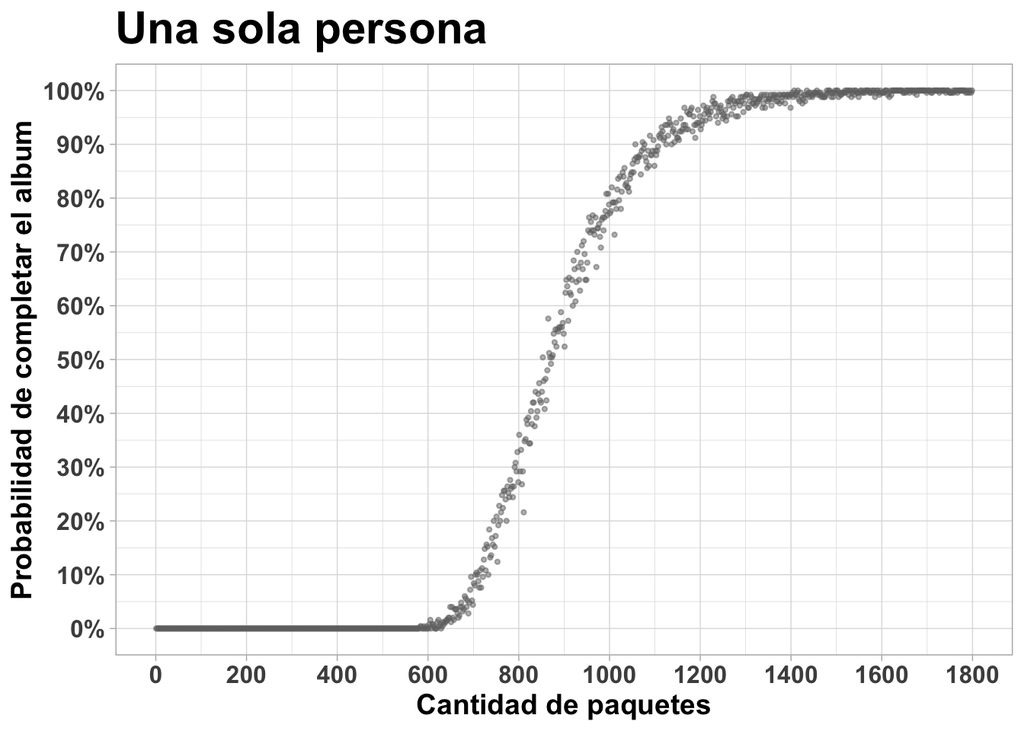

```r
completado %>% ggplot(aes(x=paquetes, y=prob_completar)) +
  geom_point(alpha = 0.5, color="gray44", size=0.8) + theme_light() +
  scale_x_continuous(breaks = seq(0, 2000, by=200)) +
  scale_y_continuous(breaks = seq(0, 100, by=10),
                     labels=scales::label_number(accuracy=1, suffix="%")) +
  labs(x="Cantidad de paquetes", y="Probabilidad de completar el album",
       title = "Una sola persona") +
  theme(axis.text=element_text(face="bold", size=12),
        plot.title = element_text(face="bold", size=22),
        axis.title = element_text(face="bold", size=14))
```

Se ve en el gráfico que se necesitan casi 1200 paquetes para llegar a una probabilidad de 90% de completar el álbum. Podemos repetir las simulaciones para 2, 5 y 10 personas:

```r
personas=2
simulaciones=250

prob_completar <- unlist(lapply(seq(1, 1800, by=2), function(x) simular_paquete(personas=2, paquetes=x, simulaciones=250)))
completado2 <- data.frame(paquetes = seq(1, 1800, by=2), prob_completar = prob_completar)
```

```r
personas=5
simulaciones=250

prob_completar <- unlist(lapply(seq(1, 1800, by=2), function(x) simular_paquete(personas=5, paquetes=x, simulaciones=250)))
completado5 <- data.frame(paquetes = seq(1, 1800, by=2), prob_completar = prob_completar)
```

```r
personas=10
simulaciones=250

prob_completar <- unlist(lapply(seq(1, 1800, by=2), function(x) simular_paquete(personas=10, paquetes=x, simulaciones=250)))
completado10 <- data.frame(paquetes = seq(1, 1800, by=2), prob_completar = prob_completar)
```

El mismo gráfico de arriba para dos personas:

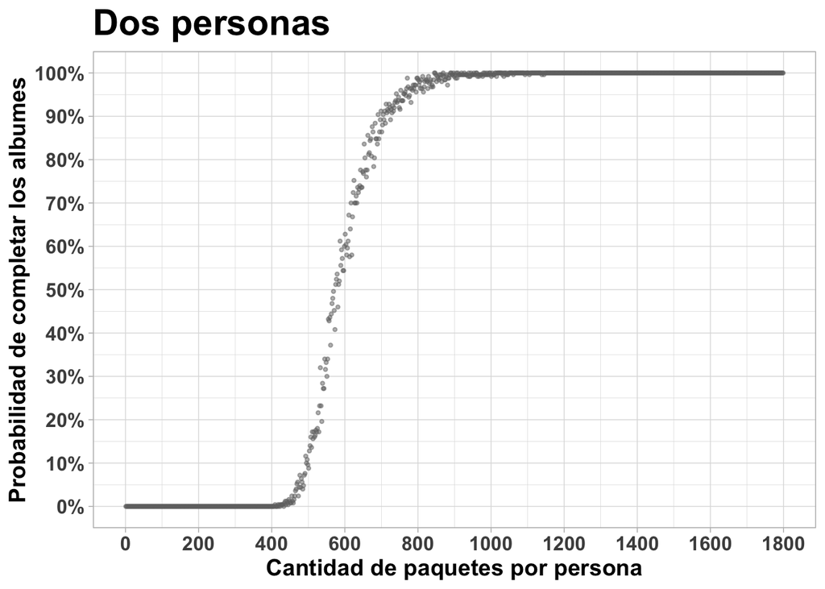

```r
completado2 %>% ggplot(aes(x=paquetes, y=prob_completar)) +
  geom_point(alpha = 0.5, color="gray44", size=0.8) + theme_light() +
  scale_x_continuous(breaks = seq(0, 2000, by=200)) +
  scale_y_continuous(breaks = seq(0, 100, by=10),
                     labels=scales::label_number(accuracy=1, suffix="%")) +
  labs(x="Cantidad de paquetes por persona", y="Probabilidad de completar los albumes",
       title = "Dos personas") +
  theme(axis.text=element_text(face="bold", size=12),
        plot.title = element_text(face="bold", size=22),
        axis.title = element_text(face="bold", size=14))
```

Para cinco:

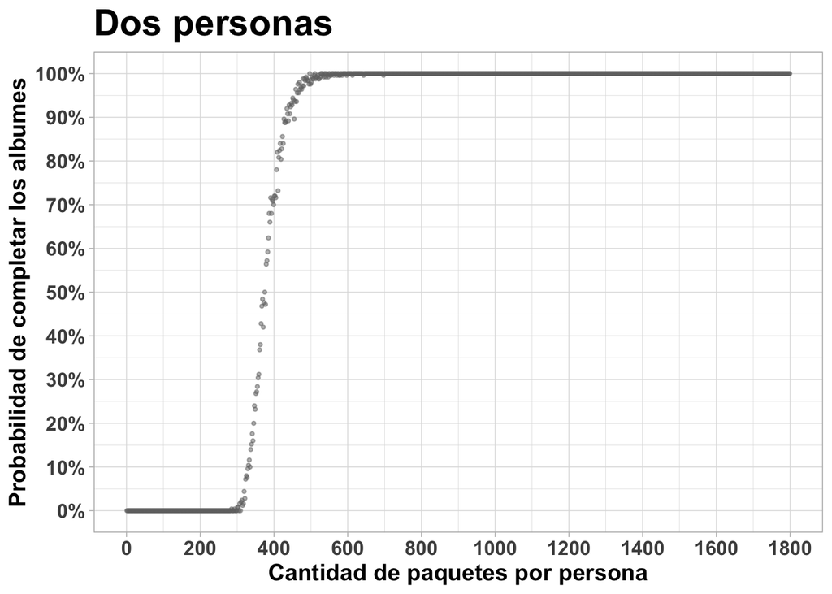

```r
completado5 %>% ggplot(aes(x=paquetes, y=prob_completar)) +
  geom_point(alpha = 0.5, color="gray44", size=0.8) + theme_light() +
  scale_x_continuous(breaks = seq(0, 2000, by=200)) +
  scale_y_continuous(breaks = seq(0, 100, by=10),
                     labels=scales::label_number(accuracy=1, suffix="%")) +
  labs(x="Cantidad de paquetes por persona", y="Probabilidad de completar los albumes",
       title = "Dos personas") +
  theme(axis.text=element_text(face="bold", size=12),
        plot.title = element_text(face="bold", size=22),
        axis.title = element_text(face="bold", size=14))
```

Y para diez:

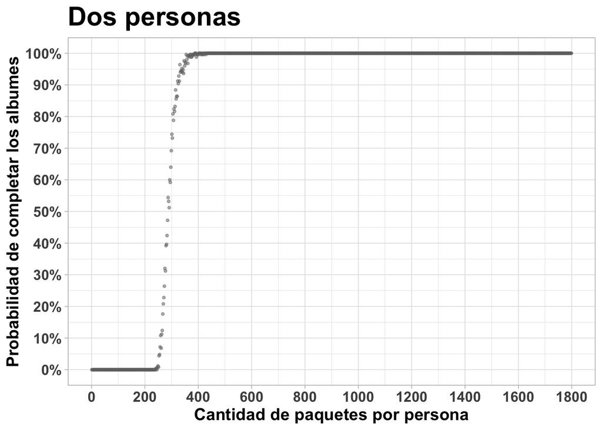

```r
completado10 %>% ggplot(aes(x=paquetes, y=prob_completar)) +
  geom_point(alpha = 0.5, color="gray44", size=0.8) + theme_light() +
  scale_x_continuous(breaks = seq(0, 2000, by=200)) +
  scale_y_continuous(breaks = seq(0, 100, by=10),
                     labels=scales::label_number(accuracy=1, suffix="%")) +
  labs(x="Cantidad de paquetes por persona", y="Probabilidad de completar los albumes",
       title = "Dos personas") +
  theme(axis.text=element_text(face="bold", size=12),
        plot.title = element_text(face="bold", size=22),
        axis.title = element_text(face="bold", size=14))
```

# Suponiendo independencia dentro de un mismo paquete

```r
personas <- 1
completado <- NULL
simulaciones <- 200
for(i in seq(1, 1800, by=2)){
  exito <- NULL
  for(j in 1:simulaciones){
  figus <-  as.data.frame(table(sample(1:638, i*personas*5, replace = TRUE)))
  exito[j] <- ifelse(nrow(figus)==638 & min(figus$Freq)>=personas, TRUE, FALSE)}
  simulacion <- data.frame(paquetes = i, prob_completar = sum(exito)/simulaciones*100)
  completado <- rbind(completado, simulacion)}

personas <- 2
completado2 <- NULL
simulaciones <- 200
for(i in seq(1, 1800, by=2)){
  exito <- NULL
  for(j in 1:simulaciones){
  figus <-  as.data.frame(table(sample(1:638, i*personas*5, replace = TRUE)))
  exito[j] <- ifelse(nrow(figus)==638 & min(figus$Freq)>=personas, TRUE, FALSE)}
  simulacion <- data.frame(paquetes = i, prob_completar = sum(exito)/simulaciones*100)
  completado2 <- rbind(completado2, simulacion)}

personas <- 5
completado5 <- NULL
simulaciones <- 200
for(i in seq(1, 1800, by=2)){
  exito <- NULL
  for(j in 1:simulaciones){
  figus <-  as.data.frame(table(sample(1:638, i*personas*5, replace = TRUE)))
  exito[j] <- ifelse(nrow(figus)==638 & min(figus$Freq)>=personas, TRUE, FALSE)}
  simulacion <- data.frame(paquetes = i, prob_completar = sum(exito)/simulaciones*100)
  completado5 <- rbind(completado5, simulacion)}

personas <- 10
completado10 <- NULL
simulaciones <- 200
for(i in seq(1, 1800, by=2)){
  exito <- NULL
  for(j in 1:simulaciones){
  figus <-  as.data.frame(table(sample(1:638, i*personas*5, replace = TRUE)))
  exito[j] <- ifelse(nrow(figus)==638 & min(figus$Freq)>=personas, TRUE, FALSE)}
  simulacion <- data.frame(paquetes = i, prob_completar = sum(exito)/simulaciones*100)
  completado10 <- rbind(completado10, simulacion)}
```

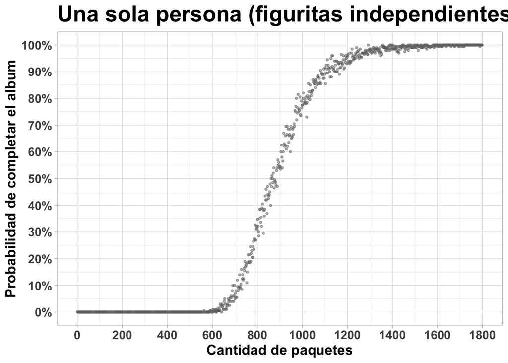

```r
completado %>% ggplot(aes(x=paquetes, y=prob_completar)) +
  geom_point(alpha = 0.5, color="gray44", size=0.8) + theme_light() +
  scale_x_continuous(breaks = seq(0, 2000, by=200)) +
  scale_y_continuous(breaks = seq(0, 100, by=10),
                     labels=scales::label_number(accuracy=1, suffix="%")) +
  labs(x="Cantidad de paquetes", y="Probabilidad de completar el album",
       title = "Una sola persona (figuritas independientes)") +
  theme(axis.text=element_text(face="bold", size=12),
        plot.title = element_text(face="bold", size=22),
        axis.title = element_text(face="bold", size=14))
```

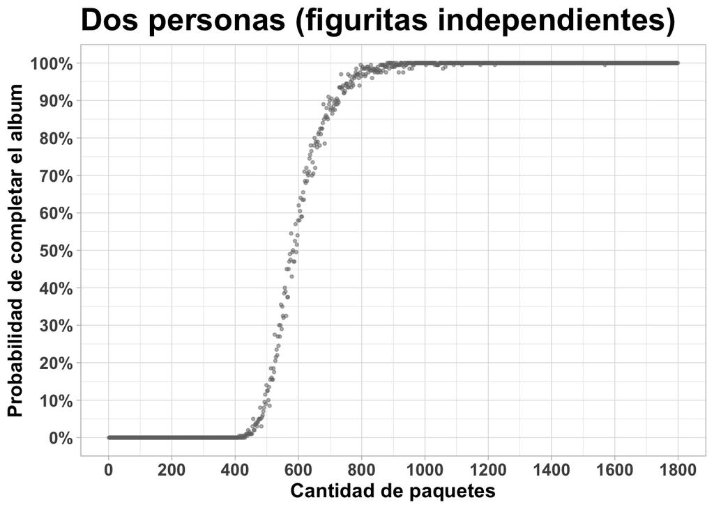

```r
completado2 %>% ggplot(aes(x=paquetes, y=prob_completar)) +
  geom_point(alpha = 0.5, color="gray44", size=0.8) + theme_light() +
  scale_x_continuous(breaks = seq(0, 2000, by=200)) +
  scale_y_continuous(breaks = seq(0, 100, by=10),
                     labels=scales::label_number(accuracy=1, suffix="%")) +
  labs(x="Cantidad de paquetes", y="Probabilidad de completar el album",
       title = "Dos personas (figuritas independientes)") +
  theme(axis.text=element_text(face="bold", size=12),
        plot.title = element_text(face="bold", size=22),
        axis.title = element_text(face="bold", size=14))
```

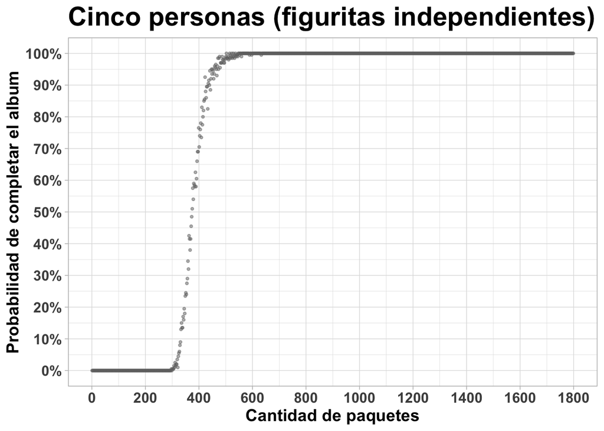

```r
completado5 %>% ggplot(aes(x=paquetes, y=prob_completar)) +
  geom_point(alpha = 0.5, color="gray44", size=0.8) + theme_light() +
  scale_x_continuous(breaks = seq(0, 2000, by=200)) +
  scale_y_continuous(breaks = seq(0, 100, by=10),
                     labels=scales::label_number(accuracy=1, suffix="%")) +
  labs(x="Cantidad de paquetes", y="Probabilidad de completar el album",
       title = "Cinco personas (figuritas independientes)") +
  theme(axis.text=element_text(face="bold", size=12),
        plot.title = element_text(face="bold", size=22),
        axis.title = element_text(face="bold", size=14))
```

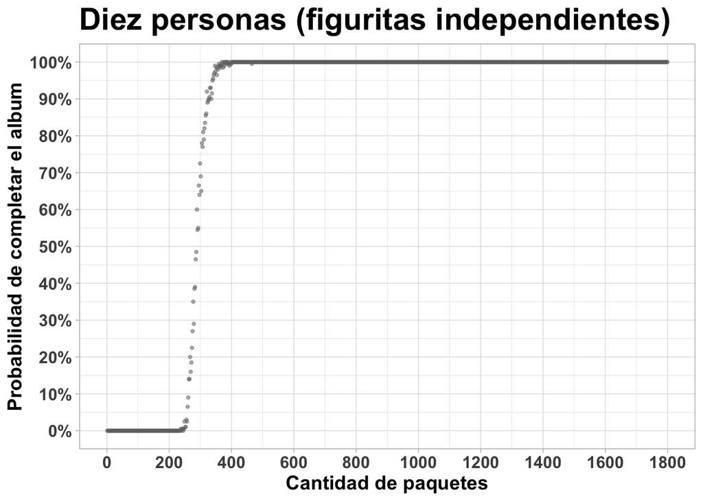

```r
completado10 %>% ggplot(aes(x=paquetes, y=prob_completar)) +
  geom_point(alpha = 0.5, color="gray44", size=0.8) + theme_light() +
  scale_x_continuous(breaks = seq(0, 2000, by=200)) +
  scale_y_continuous(breaks = seq(0, 100, by=10),
                     labels=scales::label_number(accuracy=1, suffix="%")) +
  labs(x="Cantidad de paquetes", y="Probabilidad de completar el album",
       title = "Diez personas (figuritas independientes)") +
  theme(axis.text=element_text(face="bold", size=12),
        plot.title = element_text(face="bold", size=22),
        axis.title = element_text(face="bold", size=14))
```